# Transcriptomics: Differential Expression Analysis by `DESeq2`

[Krittiyabhorn (Namthip) Kongtanawanich](https://kuchikinamthip.github.io/)

2024-09-03

I will use the count matrix from published data GSE197576 which I already managed it from my previous transcriptomic portfolio [(Count Matrix to TPM)](https://kuchikinamthip.github.io/.../CountMatrixToTPM.html) by selecting only `sgCTRL` and change it to matrix format `raw_counts_mat`.  
Here, I will download the file and name it `raw_counts_mat`.

```r
library(dplyr)
library(readr)
raw_counts <- read.csv("result/raw_counts_mat.csv")  # import .csv file
raw_counts_mat <- raw_counts[, -1] %>%
  as.matrix() # change only count values to matrix
rownames(raw_counts_mat) <- raw_counts[, 1] # add rowname
head(raw_counts_mat)
```

```
##             X01_SW_sgCTRL_Norm X02_SW_sgCTRL_Norm X11_SW_sgCTRL_Hyp
## DDX11L1                      0                  0                 0
## WASH7P                      18                 11                23
## MIR6859-1                    5                  1                 8
## MIR1302-2HG                  0                  0                 1
## MIR1302-2                    0                  0                 0
## FAM138A                      0                  0                 0
##             X12_SW_sgCTRL_Hyp
## DDX11L1                     0
## WASH7P                     45
## MIR6859-1                  12
## MIR1302-2HG                 0
## MIR1302-2                   0
## FAM138A                     0
```

## 1. Call the `DESeq2` library.

```r
library(DESeq2)
```

## 2. Manage the file format for `DESeq2` analysis

```r
# Define condition of each column
coldata <- data.frame(condition = c("normoxia", "normoxia", "hypoxia", "hypoxia"))
rownames(coldata) <- colnames(raw_counts_mat)

# Recheck whether the name is match with the defined condition
coldata
```

```
##                    condition
## X01_SW_sgCTRL_Norm  normoxia
## X02_SW_sgCTRL_Norm  normoxia
## X11_SW_sgCTRL_Hyp    hypoxia
## X12_SW_sgCTRL_Hyp    hypoxia
```

## 3. Differential gene expression analysis by `DESeq2`

This start by create a DESeq2 object (`dds`) where `raw_counts_mat` and `coldata` were used as input. This object will used condition as the main factor.

```r
dds <- DESeqDataSetFromMatrix(countData = raw_counts_mat,
                              colData = coldata,
                              design = ~ condition)
dds <- DESeq(dds)
dds
```

```
## class: DESeqDataSet
## dim: 43809 4
## metadata(1): version
## assays(4): counts mu H cooks
## rownames(43809): DDX11L1 WASH7P ... TRNT TRNP
## rowData names(22): baseMean baseVar ... deviance maxCooks
## colnames(4): X01_SW_sgCTRL_Norm X02_SW_sgCTRL_Norm X11_SW_sgCTRL_Hyp
##   X12_SW_sgCTRL_Hyp
## colData names(2): condition sizeFactor
```

To get differential gene expression, the two conditions (normoxia vs hypoxia) will be used.

```r
res <- results(dds, contrast = c("condition", "hypoxia", "normoxia"))

res
```

```
## log2 fold change (MLE): condition hypoxia vs normoxia
## Wald test p-value: condition hypoxia vs normoxia
## DataFrame with 43809 rows and 6 columns
##              baseMean log2FoldChange     lfcSE      stat      pvalue
##             <numeric>      <numeric> <numeric> <numeric>   <numeric>
## DDX11L1      0.000000             NA        NA        NA          NA
## WASH7P      23.139029       0.963409  0.597186  1.613247    0.106691
## MIR6859-1    6.038256       1.509895  1.164730  1.296347    0.194856
## MIR1302-2HG  0.224241       1.149897  4.997209  0.230108    0.818008
## MIR1302-2    0.000000             NA        NA        NA          NA
## ...               ...            ...       ...       ...         ...
## ND6         11341.547      0.9463917 0.1089003  8.690442 3.61032e-18
## TRNE            0.000             NA        NA        NA          NA
## CYTB        55688.609      0.0311024 0.0498182  0.624317 5.32419e-01
## TRNT            0.000             NA        NA        NA          NA
## TRNP          396.035      2.0267306 0.1542223 13.141616 1.90122e-39
##                    padj
##               <numeric>
## DDX11L1              NA
## WASH7P         0.201369
## MIR6859-1      0.325988
## MIR1302-2HG          NA
## MIR1302-2            NA
## ...                 ...
## ND6         4.61793e-17
## TRNE                 NA
## CYTB        6.81143e-01
## TRNT                 NA
## TRNP        6.79217e-38
```

## 4. Observe the DESeq2 results by visualization

### 4.1 Volcano plot

The volcano plot will label the most differential express genes either upregulation or downregulation. Thus, I firstly define genes that we will label`genes_to_label`.

```r
genes_to_label <- res %>%
  as.data.frame() %>%
  tibble::rownames_to_column(var = "gene") %>%
  filter(!stringr::str_detect(gene, "LOC"),
         abs(log2FoldChange) >= 2.5,
         padj <= 0.001)

head(genes_to_label)
```

```
##     gene   baseMean log2FoldChange      lfcSE      stat       pvalue
## 1 ERRFI1 4276.99893       2.743400 0.06794033 40.379552 0.000000e+00
## 2   NPPB   24.98085       4.444004 0.87020968  5.106820 3.276254e-07
## 3   CTRC   13.53926       4.600708 1.22398085  3.758807 1.707256e-04
## 4  PADI2   46.53917       2.822299 0.47225085  5.976270 2.283046e-09
## 5   GJB4   87.79583       2.767811 0.34203226  8.092251 5.857196e-16
## 6   EDN2  362.80128       3.553805 0.19288396 18.424575 8.344272e-76
##           padj
## 1 0.000000e+00
## 2 1.723543e-06
## 3 6.179012e-04
## 4 1.494092e-08
## 5 6.592276e-15
## 6 8.218873e-74
```

Moreover, I also want to label the significantly different genes by color. Therefore, the significant(`sig`) and not significant(`not_sig`) genes will be defined by the code below for the labeling purpose.

```r
res_label <- res %>%
  as.data.frame() %>%
  tibble::rownames_to_column(var = "gene") %>%
  mutate(sig = case_when(
    !stringr::str_detect(gene, "LOC") &
      abs(log2FoldChange) >= 2.5 &
      padj <= 0.001 ~ "sig",
    TRUE ~ "not_sig"
  ))

head(res_label)
```

```
##          gene   baseMean log2FoldChange     lfcSE      stat    pvalue      padj
## 1     DDX11L1  0.0000000             NA        NA        NA        NA        NA
## 2      WASH7P 23.1390286      0.9634086 0.5971859 1.6132475 0.1066908 0.2013691
## 3   MIR6859-1  6.0382555      1.5098946 1.1647303 1.2963470 0.1948560 0.3259878
## 4 MIR1302-2HG  0.2242407      1.1498966 4.9972093 0.2301077 0.8180080        NA
## 5   MIR1302-2  0.0000000             NA        NA        NA        NA        NA
## 6     FAM138A  0.0000000             NA        NA        NA        NA        NA
##       sig
## 1 not_sig
## 2 not_sig
## 3 not_sig
## 4 not_sig
## 5 not_sig
## 6 not_sig
```

Now, I create the volcano plot using `ggplot2` library and use `ggrepel` to prevent label overlap. Additionally, I add horizontal and vertical lines to mark the highly significant level based on p-values and fold change, respectively.

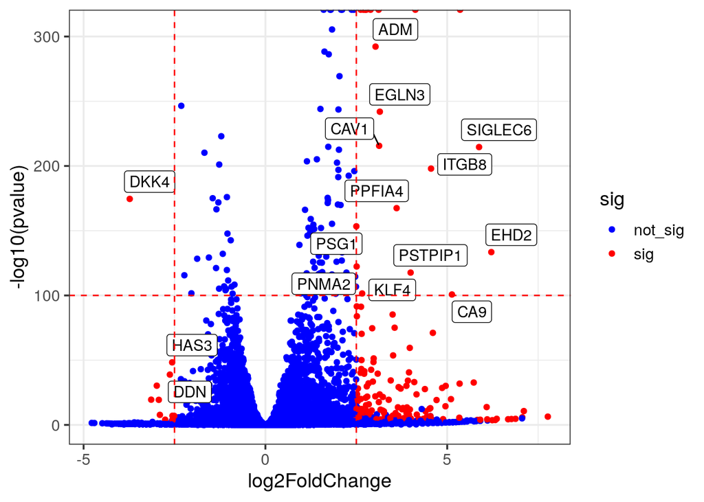

```r
library(ggplot2)
library(ggrepel)

ggplot(res_label, aes(x = log2FoldChange, y = -log10(pvalue))) +
  geom_point(aes(color = sig)) +
  scale_color_manual(values = c("blue", "red")) +
  ggrepel::geom_label_repel(data = genes_to_label, aes(label = gene))+
  geom_hline(yintercept = 100, linetype = 2, color = "red") +
  geom_vline(xintercept = c(-2.5, 2.5), linetype = 2, color = "red")+
  theme_bw(base_size = 14)
```

### 4.2 Principal Component Analysis (PCA)

```r
# Calculate the normalized data for PCA plot
vsd <- vst(dds, blind=FALSE)

normalized_counts <- assay(vsd) %>% as.matrix()

# Calculate the principal components
pca_prcomp <- prcomp(t(normalized_counts), center = TRUE, scale. = FALSE)

# This is the PC values
pca_prcomp$x
```

```
##                          PC1       PC2       PC3          PC4
## X01_SW_sgCTRL_Norm -15.49523  1.837809 -2.832274 7.632783e-14
## X02_SW_sgCTRL_Norm -15.46292 -1.841055  2.834578 7.497648e-14
## X11_SW_sgCTRL_Hyp   15.48539 -3.254055 -1.602016 7.821088e-14
## X12_SW_sgCTRL_Hyp   15.47277  3.257301  1.599712 9.024899e-14
```

```r
# Create a DataFrame for visualization
PC1_and_PC2 <- data.frame(PC1 = pca_prcomp$x[, 1], PC2 = pca_prcomp$x[, 2], type = rownames(pca_prcomp$x))

PC1_and_PC2
```

```
##                          PC1       PC2               type
## X01_SW_sgCTRL_Norm -15.49523  1.837809 X01_SW_sgCTRL_Norm
## X02_SW_sgCTRL_Norm -15.46292 -1.841055 X02_SW_sgCTRL_Norm
## X11_SW_sgCTRL_Hyp   15.48539 -3.254055  X11_SW_sgCTRL_Hyp
## X12_SW_sgCTRL_Hyp   15.47277  3.257301  X12_SW_sgCTRL_Hyp
```

This will generate the PCA plot.

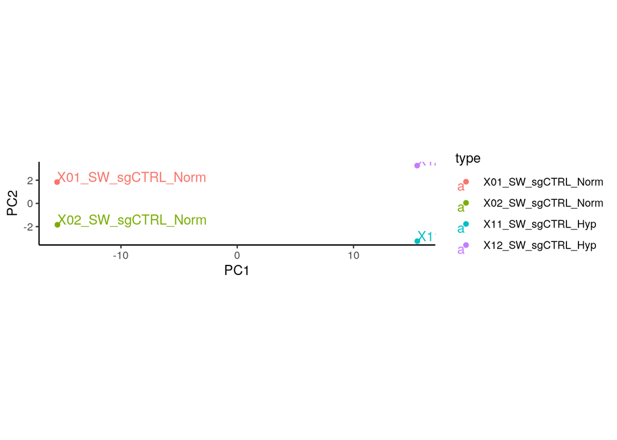

```r
# Create a PCA plot
ggplot(PC1_and_PC2, aes(x = PC1, y = PC2, col = type)) +
  geom_point() +
  geom_text(aes(label = type), hjust = 0, vjust = 0) +
  coord_fixed()+
  theme_classic()
```

### 4.3 Heatmap

```r
significant_genes <- res %>%
  as.data.frame() %>%
  filter(padj <= 0.01, abs(log2FoldChange) >= 2) %>%
  rownames()

head(significant_genes, 10)
```

```
##  [1] "HES2"         "ERRFI1"       "NPPB"         "CTRC"         "ESPNP"
##  [6] "PADI2"        "CDA"          "LOC105376863" "CSMD2"        "GJB4"
```

I will use `ComplexHeatmap` for a heatmap plotting.

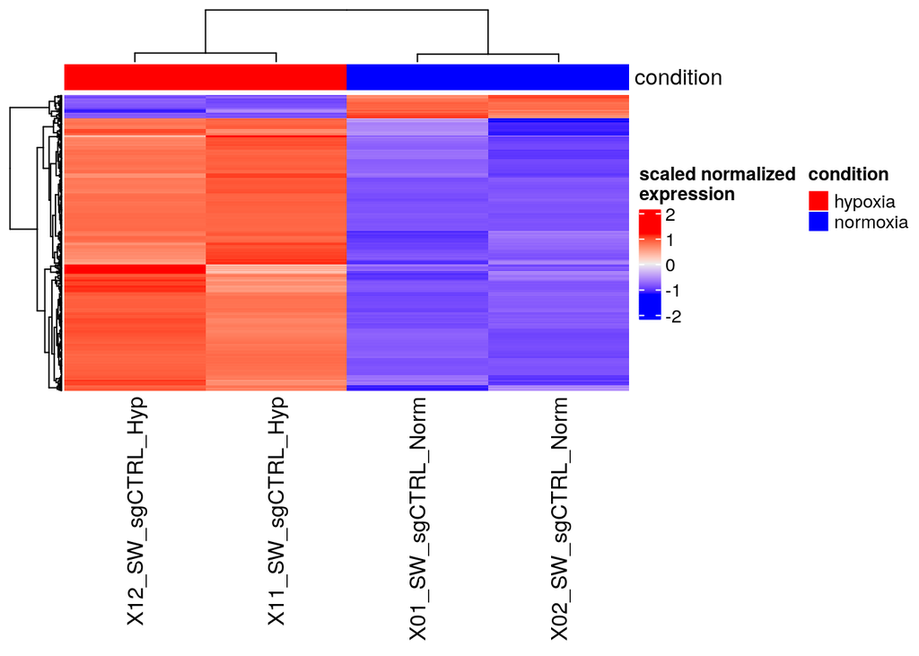

```r
library(ComplexHeatmap)
significant_mat <- normalized_counts[significant_genes, ]

col_anno <- HeatmapAnnotation(
  df = coldata,
  col = list(condition = c("hypoxia" = "red", "normoxia" = "blue"))
)

Heatmap(
  t(scale(t(significant_mat))),
  top_annotation = col_anno,
  show_row_names = FALSE,
  name = "scaled normalized\nexpression"
)
```

## 5. Over-Representation Analysis (ORA)

```r
library(org.Hs.eg.db)
library(clusterProfiler)

#convert gene symbol to Entrez ID

significant_genes_map<- clusterProfiler::bitr(geneID = significant_genes,
                      fromType="SYMBOL", toType="ENTREZID",
                      OrgDb="org.Hs.eg.db")

head(significant_genes_map)
```

```
##   SYMBOL ENTREZID
## 1   HES2    54626
## 2 ERRFI1    54206
## 3   NPPB     4879
## 4   CTRC    11330
## 5  ESPNP   284729
## 6  PADI2    11240
```

### 5.2 Selecting Background Genes

```r
## background genes are genes that are detected in the RNAseq experiment
background_genes<- res %>%
  as.data.frame() %>%
  filter(baseMean != 0) %>%
  tibble::rownames_to_column(var = "gene") %>%
  pull(gene)


res_df<- res %>%
  as.data.frame() %>%
  filter(baseMean != 0) %>%
  tibble::rownames_to_column(var = "gene")

background_genes_map<- bitr(geneID = background_genes,
                            fromType="SYMBOL",
                            toType="ENTREZID",
                      OrgDb="org.Hs.eg.db")

head(background_genes_map)
```

```
##        SYMBOL  ENTREZID
## 1      WASH7P    653635
## 2   MIR6859-1 102466751
## 3 MIR1302-2HG 107985730
## 5   LOC729737    729737
## 6      WASH9P 100996442
## 7    MIR12136 113219467
```